# Лабораторная работа №1

Основы информационной безопасности

Иванов Сергей Владимирович, НПИбд-01-23

Российский университет дружбы народов, Москва, Россия

## Цель работы

Целью данной работы является приобретение практических навыков установки операционной системы на виртуальную машину, настройки минимально необходимых для дальнейшей работы сервисов.

## Задание

1. Создать виртуальную машину
2. Установить ОС на виртуальную машину
3. Настроить систему

# Выполнение работы

## Скачиваем дистрибутив

Необходимо скачать дистрибутив Rocky https://rockylinux.org/download

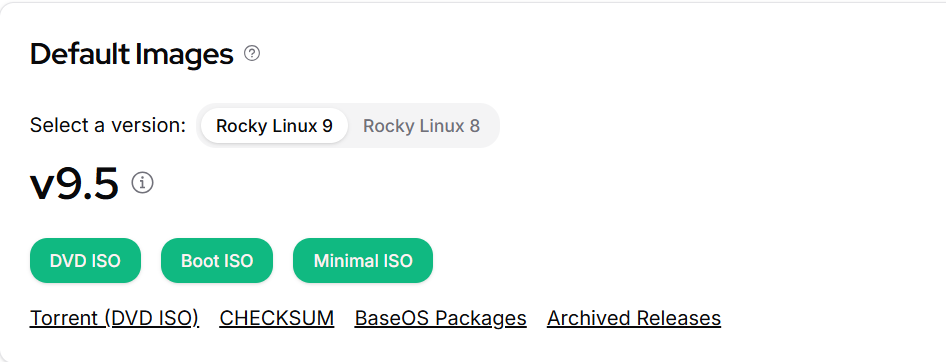

Скачивание дистрибутива

## Создание виртуальной машины

Укажем имя машины и подключим наш скачанный образ Rocky.

[figure not shown]

Создание виртуальной машины

## Создание виртуальной машины

Укажем объём памяти и количество виртуальных процессоров. Я указал 4096 мб оперативной памяти и 4 ЦП. Далее укажем обьем диска 40гб.

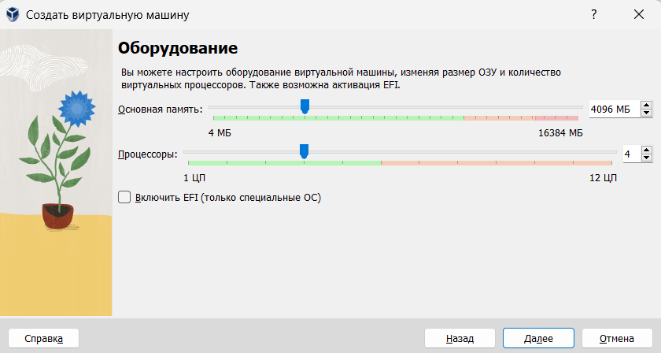

Указываем характеристики

## Виртуальный жесткий диск

Далее укажем обьем диска 40гб.

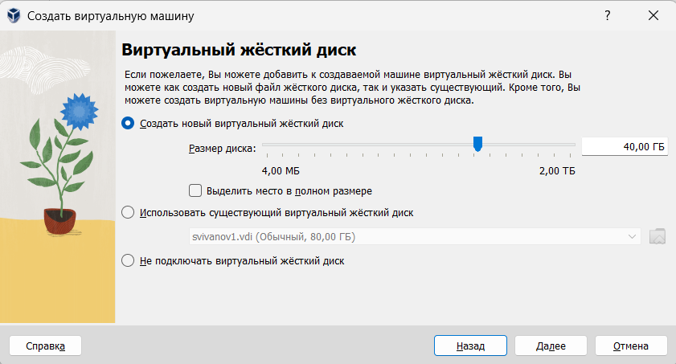

Виртуальный жесткий диск

## Запуск виртуальной машины

Запускаем виртуальную машину.

[figure not shown]

Запуск виртуальной машины

## Выбор языка интерфейса

Выбираем английский язык интерфейса.

[figure not shown]

Установка языка

## Выбор программ

Выбираем необходимые программы.

[figure not shown]

Выбор программ

## Отключение KDUMP

Далее нам необходимо отключить KDUMP

[figure not shown]

Отключение KDUMP

## Место установки

Выбираем место установки

[figure not shown]

Место установки

## Сеть и имя узла

Включим сетевое соединение и укажем имя узла

[figure not shown]

Сеть и имя узла

## Установка пароля для root

Установим пароль для root

[figure not shown]

Установка пароля для root

## Задаем пользователя

Задаем локального пользователя

[figure not shown]

Задаем пользователя

## Окно настройки установки образа

Нажмимаю на Begin Installation для начала установки.

[figure not shown]

Окно установки образа

## Завершение установки ОС

После завершения установки перезапускаю систему

[figure not shown]

Завершение установки ОС

## Дополнения гостевой ОС

Подключаю образ диска дополнений гостевой ОС.

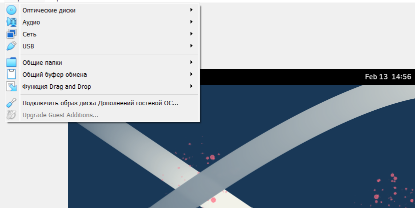

Подключение Диска дополнений гостевой ОС

## Дополнения гостевой ОС

Запускаю образ диска дополнений гостевой ОС.

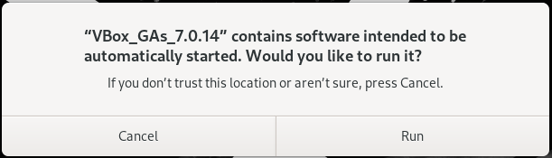

Запуск образа диска

# Домашнее задание

## Версия ядра Linux (Linux version).

Чтобы посмотреть версию ядра, можно воспользоваться командой dmesg | grep -i ‘linux version’. Версия ядра: 5.14.0-427.

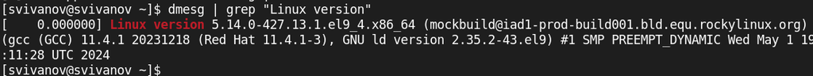

Версия ядра

## Частота процессора (Detected Mhz processor).

Частоту процессора можно узнать командой dmesg | grep -I “MHz”. Частота процессора: 2688.004 MHz.

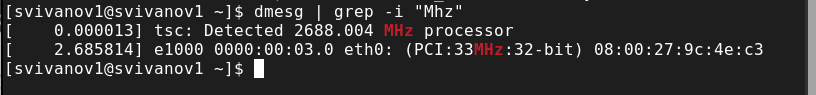

Частота процессора

## Модель процессора (CPU0).

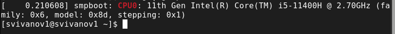

Модель процессора

## Объем доступной оперативной памяти (Memory available).

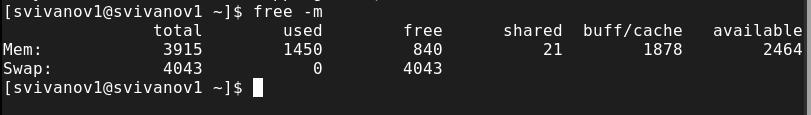

Объем оперативной памяти

## Тип обнаруженного гипервизора (Hypervisor detected).

Тип обнаруженного гипервизора можно посмотреть командой dmesg | grep -I “hypervisor detected”. В моём случае: KVM.

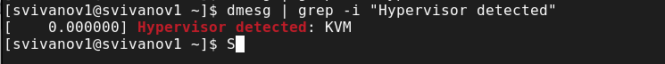

Тип гипервизора

## Тип файловой системы корневого раздела.

Тип файловой системы корневого раздела можно посмотреть командой dmesg | grep -I “filesystem”

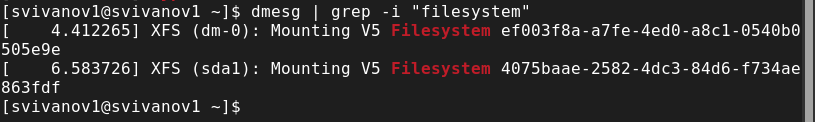

Тип файловой системы

## Последовательность монтирования файловых систем.

Последовательность монтирования файловых систем можно посмотреть командой dmesg | grep -i “mount”

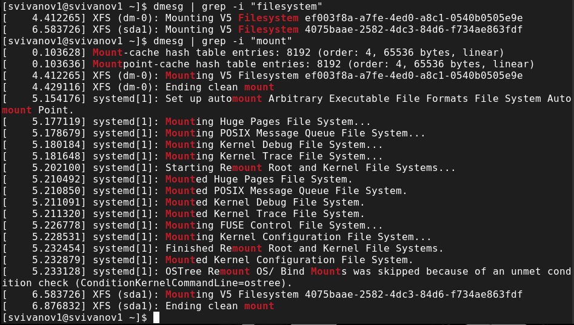

Последовательность монтирования файловых систем

# Вывод

## Вывод

В ходе работы были приобретены практические навыки установки виртуальной машины и операционной системы на виртуальную машину, а также настройки минимально необходимых для дальнейшей работы сервисов.

## Список литературы

1. Dash, P. Getting Started with Oracle VM VirtualBox / P. Dash. – Packt Publishing Ltd, 2013. – 86 сс.

2. Colvin, H. VirtualBox: An Ultimate Guide Book on Virtualization with VirtualBox. VirtualBox / H. Colvin. – CreateSpace Independent Publishing Platform, 2015. – 70 сс.

3. Vugt, S. van. Red Hat RHCSA/RHCE 7 cert guide : Red Hat Enterprise Linux 7 (EX200 and EX300) : Certification Guide. Red Hat RHCSA/RHCE 7 cert guide / S. van Vugt. – Pearson IT Certification, 2016. – 1008 сс.

4. Робачевский, А. Операционная система UNIX / А. Робачевский, С. Немнюгин, О. Стесик. – 2-е изд. – Санкт-Петербург : БХВ-Петербург, 2010. – 656 сс.

5. Немет, Э. Unix и Linux: руководство системного администратора. Unix и Linux / Э. Немет, Г. Снайдер, Т.Р. Хейн, Б. Уэйли. – 4-е изд. – Вильямс, 2014. – 1312 сс.

6. Колисниченко, Д.Н. Самоучитель системного администратора Linux : Системный администратор / Д.Н. Колисниченко. – Санкт-Петербург : БХВ-Петербург, 2011. – 544 сс.

7. Robbins, A. Bash Pocket Reference / A. Robbins. – O’Reilly Media, 2016. – 156 сс.